# SAE 4.01: Economie écologique

Chapitre 0: Présentation de la SAE

Thomas Delcey

thomas.delcey@u-bourgogne.fr

Université de Bourgogne

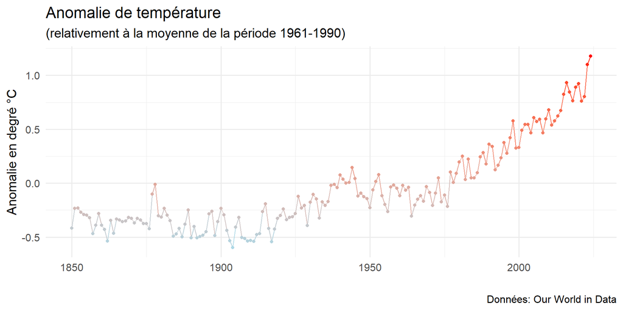

**Important**

Il s’agit de la moyenne des régions terrestres *et* océaniques, les continents se réchauffent plus vite.

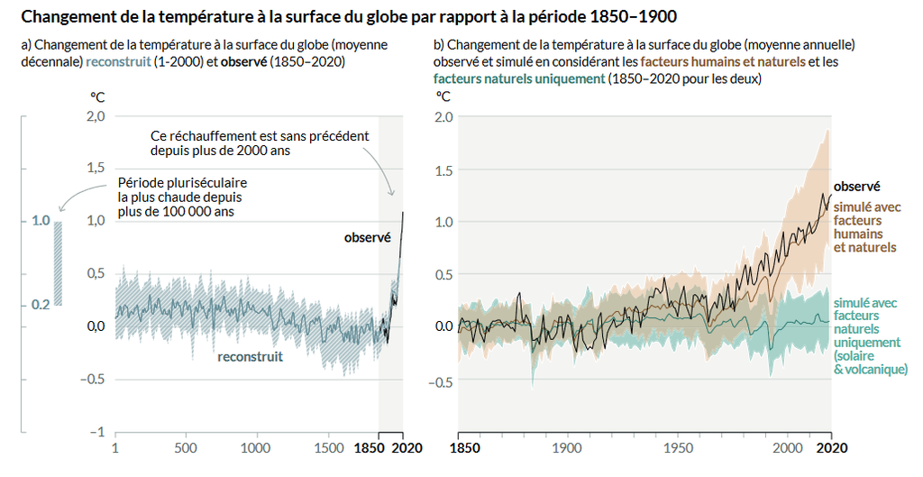

Source: 6eme [rapport du GIEC](https://www.ipcc.ch/report/ar6/wg1/downloads/report/IPCC_AR6_WG1_SPM_French.pdf)

**Note**

L’intégralité des rapports du GIEC sont disponibles gratuitement en ligne https://www.ipcc.ch.

### L’anthropocène

> “L’anthropocène [l’ère de l’être humain] est une proposition d’époque géologique pour caractériser l’influence actuelle de l’être humain sur la géologie et les écosystèmes” (wikipedia).
- Cette notion caractérise la période depuis la révolution industrielle et l’émergence des économies globalisées.

**L’anthropocène**

L’anthropocène n’est pas une notion scientifique consensuelle en géologie mais le terme est souvent utilisé dans d’autres disciplines pour caractériser l’influence de l’homme sur la planète.

### Economie et climat

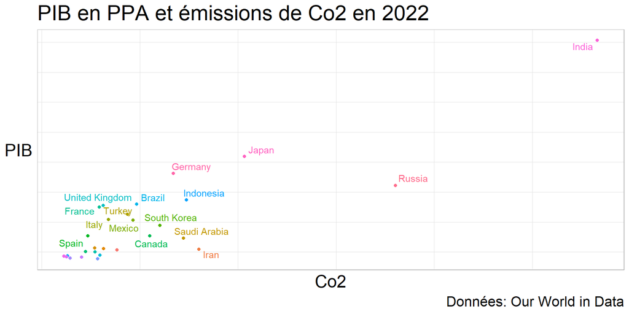

### Economie et climat

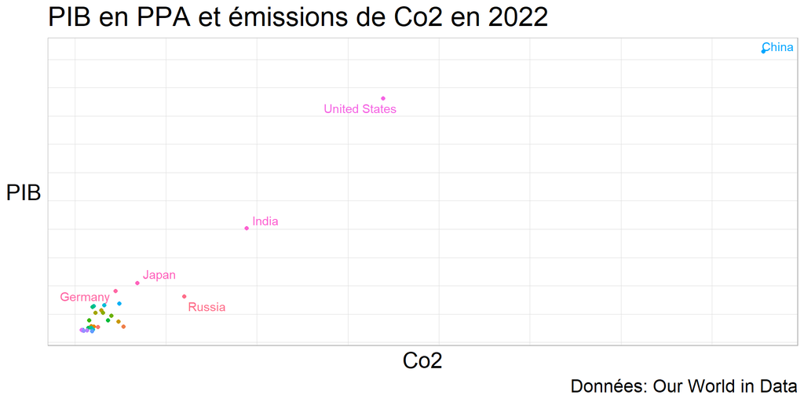

### Le découplage PIB et émissions

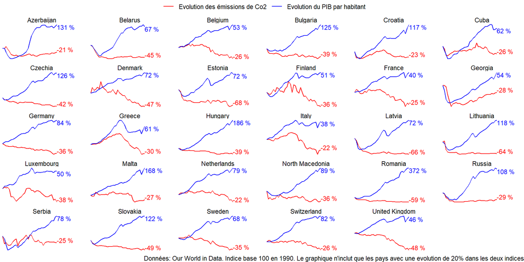

### Objectifs de cette SAE

- Comprendre les principaux enjeux de la crise climatique:
  - qu’est-ce qui réchauffe le climat ?
- Comprendre la relation entre climat et économie:
  - qui réchauffe le climat ? Quels secteurs ?
- Appréhender les solutions à la crise climatique à l’échelle individuelle du consommateur et d’une entreprise.

### L’équipe

- Thomas Delcey, maitre de conférences en économie.
- Mounir Kheyi, expert comptable et spécialiste des questions environnementales.
- Harald Lhomme, ingénieur et consultant stratégie climat.

### Sujet

> Vous êtes mandatées par le conseil d’administration d’une entreprise (de votre choix) afin de l’aider à réaliser sa transition écologique. L’entreprise aimerait adopter la qualité de société à mission introduite par la loi Pacte de 2019 afin de se fixer un objectif environnemental.

> Vous devez réaliser une analyse de l’entreprise afin d’identifier ces risques environnementaux et l’empreinte carbone de ces produits. A partir de cette analyse, vous proposerez une mission à l’entreprise à travers le cadre strict de qualité de société à mission.

### La société à mission

> “Le terme « entreprise à mission » (ou société à mission) désigne en France les formes d’entreprise qui se donnent statutairement une finalité d’ordre social ou environnemental en plus du but lucratif.” (wikipedia)
- CM avec Mr. Mounir Kheyi le jeudi 6 février 2025 à 11h.

### Le choix de l’entreprise

- Le choix de l’entreprise n’a que peu d’importance dans l’absolu.
- C’est surtout le **secteur d’activité** choisi qui va orienter votre travail.
  - Beaucoup de possibilités: agriculture, textile, banque ou finance, industrie, etc.
- Choix de l’entreprise a validé avec Mr. Kheyi en TD ;

### Les risques environnementaux de l’entreprise

- Vous devez réaliser une analyse de l’entreprise afin identifier ces risques environnementaux ;
- Les risques environnementaux sont doubles:
  1. L’impact de l’environnement sur l’entreprise.
  2. L’impact de l’entreprise sur l’environnement.

### L’impact de l’environnement sur l’entreprise

- Changement de l’environnement **économique**:
  - Evolution des coûts de production;
  - Changement de comportement des consommateurs.
- Changement de l’environnement **juridique**:
  - Réglementations ;
  - Fiscalités.

### L’impact de l’entreprise sur l’environnement.

Le bilan carbone de l’ADEME:

- Scope 1: les émissions directes.
- Scope 2: les émissions indirectes.
- Scope 3:les autres émissions indirectes.

**Note**

L’ADEME ou Agence de l’environnement et de la maîtrise de l’énergie est la principale agence publique chargée de la mise en oeuvre des politiques environnementales.

### Calculer l’empreinte carbone d’un produit

- Obligation de se focaliser sur l’émission de GAES (d’autres facteurs sociaux et environnementaux peuvent être évoqués).
- Analyser le cycle de vie du produit:
  - Production des matières premières;
  - Mise en forme des matières premières;
  - Assemblage et distribution;
  - Utilisation du produit;
  - La fin de vie.

### Evaluation

- Vous défendrez votre travail devant le conseil d’administration de l’entreprise sous le format d’un **poster** (projeter sur un écran) que vous présenterez en **5 minutes**.
- Vous serez ensuite potentiellement interrogé pendant **15 minutes** sur:
  - Les principaux enjeux de la crise climatique (vu avec moi en CM);
  - Votre démarche d’adoption de la qualité de société à mission (vu en TD avec Mr. Kheyi).

### Le poster

- Le poster doit inclure les choses suivantes:
  - L’identification du risque environnementale de l’entreprise;
  - Une proposition d’*adaptation* ou d’*attenuation*;
  - Sa mise en place dans le cadre de la qualité de société à mission.

### Le poster

- Le poster est une grande affiche qui présente l’ensemble des éléments sur une page;
- Vous pouvez rajouter des slides pour préparer les réponses aux questions:
  - Présentation des sources utilisées;
  - Elements supplémentaires de l’analyse.

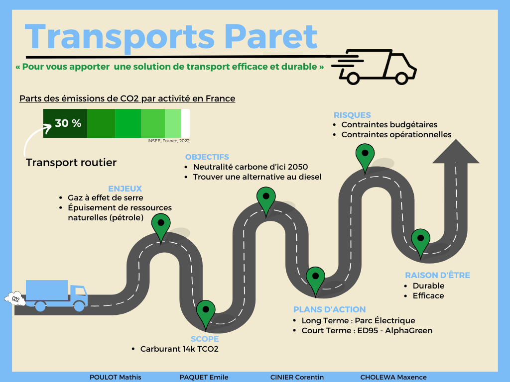

Exemple d’un travail de l’année 2024

### Organisation et calendrier

- Formation des groupes:
  - Groupes de 4 personnes au sein **d’un même groupe TD** ;
  - Les groupes sont à constituer au plus tard pour le **mercredi 3 février 2025** ;
  - Des propositions pour les entreprises doivent être données au plus tard le **mercredi 10 février 2025**.

### Organisation et calendrier

- Le travail commence maintenant:
  - Du 15 janvier au 30 janvier 2025: fresques pour le climat;
  - A partir de février, enseignements en CM ou TD jusqu’à fin mars avec Mr. Mounir Kheyi et moi;
  - Prise de rendez-vous par mail pour un entretien individuel.

### Les évaluations

- Semaine du 31 mars 2024;
- Répétition et formation avec **Harald Lhomme**;
- Soutenance entre le 7 avril et le 11 avril 2025.

### Méthodologie

- Le choix des sources est crucial. Privilégiez:
  - Les ressources de la SAE;
  - Les institutions publiques spécialisées:
    - [Haut Conseil pour le Climat](https://www.hautconseilclimat.fr/);
    - [Agence de la transition climatique](https://agirpourlatransition.ademe.fr/entreprises/);
    - [Citepa](https://www.citepa.org/explorateur-de-donnees/);
    - [impactco2.fr](https://impactco2.fr/outils/habillement/tshirtencoton).
  - Certains sites spécialisées:
    - Le monde (Stéphane Foucart, Audrey Garric, Nabil Wakim);
    - [Chaleur Humaine](https://www.lemonde.fr/podcast-chaleur-humaine/);
    - [Bon pote](https://bonpote.com/);
    - [Le reveilleur](https://www.youtube.com/channel/UC1EacOJoqsKaYxaDomTCTEQ).

### Exemple, bilan carbone d’une voiture électrique

- **Utilisation**:
  - *Clio essence*: 185 grammes d’eCO<sub>2</sub> par km.
  - *Zoé éléctrique*: 12 grammes d’eCO<sub>2</sub> par km.
- **Fabrication**:
  - *Clio essence*: 6 tonnes d’eCO<sub>2</sub>.
  - *Zoé éléctrique*: 9 tonnes d’eCO<sub>2</sub>.

[Source: le reveilleur, la voiture éléctrique est-elle écologique ?](https://www.youtube.com/watch?v=zjaUqUozwdc)

### Exemple, bilan carbone d’une voiture électrique

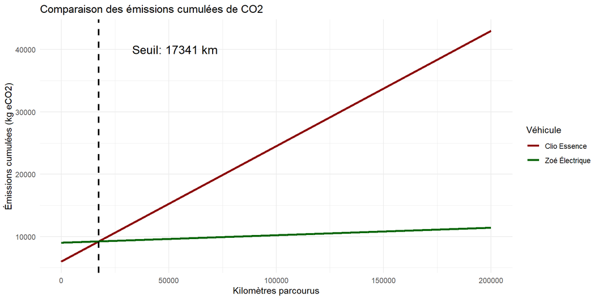

### Exemple, bilan carbone d’une voiture électrique

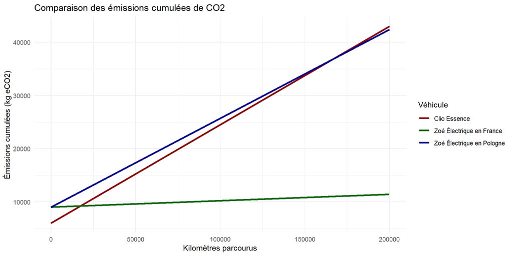

Autres enjeux et subtilités: citadine vs SUV, faisabilité économique (prix essence vs éléctricité), autre pollutions (particules fines).

### Solutions et greenwashing

[video not shown]